# BIOSTAT_696_HW4

Ben Denis Shaffer

November 27, 2016

In this analysis we will be working with crime data in the Baltimore county and Baltimore city. First we map the crime incidents together with population measures across locations in Baltimore. From the plot it appears that the spatial process is clustered. Specifically crime incidents appear to clustered in more populated areas. This does intuitively make some sense, since there are more subjects to commit crimes against in more populated areas.

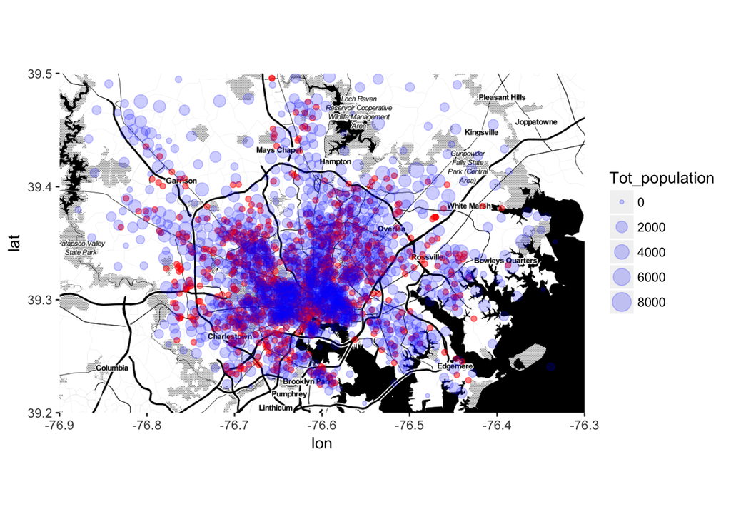

```r
crime = read.table("Crime_Baltimore.txt", header = TRUE)
pop = read.table("Baltimore_population.txt", header = TRUE)


loc = c(-76.9, 39.2, -76.3, 39.5)
map <- get_map(location = loc, source = "google", maptype = "toner")
map <- ggmap(map)
map <- map + geom_point(data = crime, aes(x = Lon, y = Lat), alpha = 0.5 , fill = "red", col = "red")
map <- map + geom_point(data = pop, aes(x = Lon, y = Lat, size = Tot_population), fill = "blue", col = "blue", alpha = 0.2)
map
```

Now we test this hypothesis that the point process is a clustered Poisson process. To do this we map the crime data to a shape file of Baltimore and create a point process object. We then estimate the K and L functions.

```r
setwd("~/Box Sync/UM Fall 2016/BIOSTAT 696/Data/tl_2016_us_county")
balt_shape = shapefile("tl_2016_us_county.shp")
balt_shape <- balt_shape[paste(balt_shape$GEOID) == "24005" | paste(balt_shape$GEOID) == "24510",]

window <- as.owin(balt_shape)
crime_ppp <- ppp(x = crime$Lon, y = crime$Lat, window = window)
pop_ppp <- ppp(x = pop$Lon, y = pop$Lat, window = window)
```

```r
K_crime = Kest(crime_ppp)

env_K_crime <- envelope(crime_ppp, fun = Kest, nrank = 1, nsim = 9)
```

```
## Generating 9 simulations of CSR  ...
## 1, 2,  [etd 10:09] 3,  [etd 9:31] 4,
##  [etd 7:33] 5,  [etd 5:56] 6,  [etd 4:20] 7,  [etd 2:51] 8,
##  [etd 1:46]  9.
##
## Done.
```

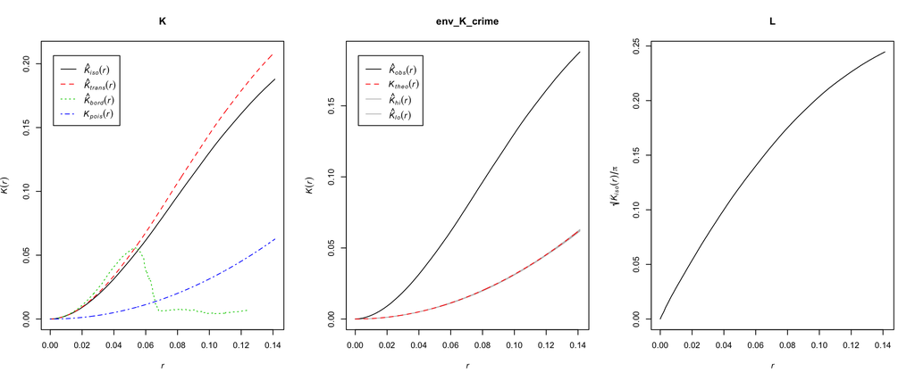

```r
par(mfrow = c(1,3))
plot(K_crime, main = "K")
plot(env_K_crime)
plot(K_crime, sqrt(iso/pi) ~ r, main = "L")
```

We observe concavity for the L function. This suggests clustering in the point process. The K function is also not convex. Based on the K and L functions the point process is not regular.

Next we preform a Chi^2 test to test whether the process is homogeneous, regular, or clustered:

```r
quadrat.test(crime_ppp)
```

```
##
##  Chi-squared test of CSR using quadrat counts
##  Pearson X2 statistic
##
## data:  crime_ppp
## X2 = 4302.5, df = 21, p-value < 2.2e-16
## alternative hypothesis: two.sided
##
## Quadrats: 22 tiles (irregular windows)
```

```r
quadrat.test(crime_ppp, alternative="regular")
```

```
##
##  Chi-squared test of CSR using quadrat counts
##  Pearson X2 statistic
##
## data:  crime_ppp
## X2 = 4302.5, df = 21, p-value = 1
## alternative hypothesis: regular
##
## Quadrats: 22 tiles (irregular windows)
```

```r
quadrat.test(crime_ppp, alternative="clustered")
```

```
##
##  Chi-squared test of CSR using quadrat counts
##  Pearson X2 statistic
##
## data:  crime_ppp
## X2 = 4302.5, df = 21, p-value < 2.2e-16
## alternative hypothesis: clustered
##
## Quadrats: 22 tiles (irregular windows)
```

Now we do a quadrant test using the Monte Carlo approach to test if the process is homogeneous or clustered:

```r
quadrat.test(crime_ppp, alternative="clustered", method="M", nsim=4999)
```

```
##
##  Conditional Monte Carlo test of CSR using quadrat counts
##  Pearson X2 statistic
##
## data:  crime_ppp
## X2 = 4302.5, p-value = 2e-04
## alternative hypothesis: clustered
##
## Quadrats: 22 tiles (irregular windows)
```

In the test above a clustered process is the alternative hypothesis, while a homogeneous process is the null hypothesis. Based on the p-value of `2e-04` The tests suggests that we reject the null hypothesis in favor of conjecturing that the process is clustered.

Next we estimate the intensity function for crime in Baltimore and plot the density of crime instances. We choose a bandwidth that minimizes the mean squared error:

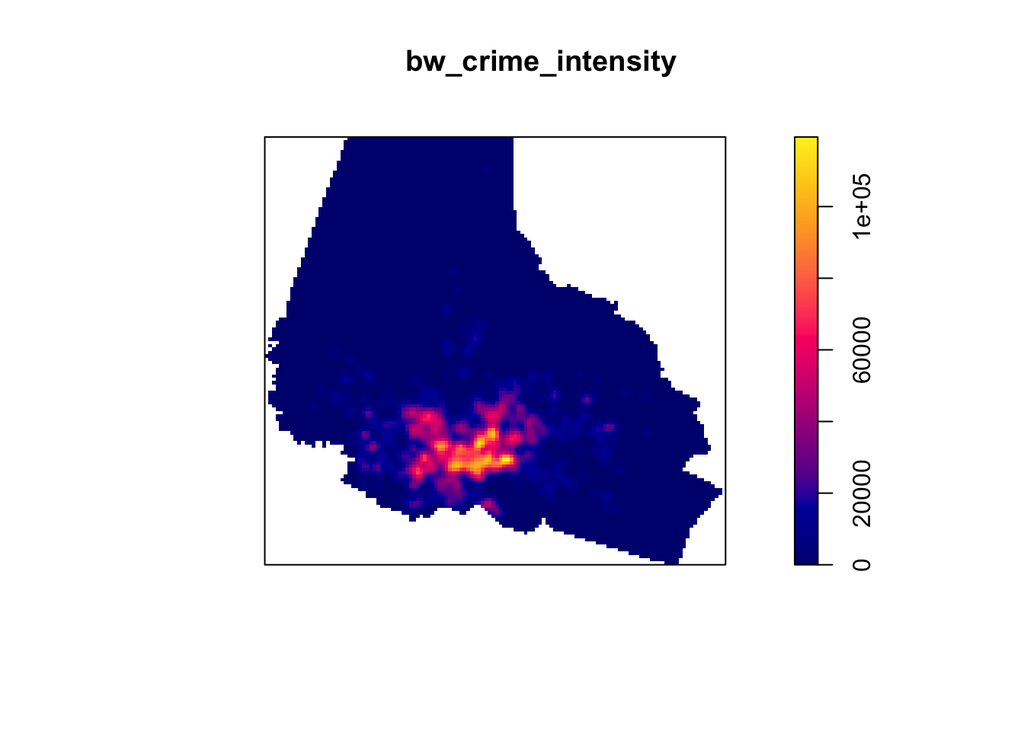

```r
crime_point <- matrix(NA, nrow = length(crime_ppp$x), ncol = 2)
crime_point[,1] <- crime_ppp$x
crime_point[,2] <- crime_ppp$y

crime_poly <- as.points(c(min(crime_point[,1]),max(crime_point[,1]),max(crime_point[,1]),min(crime_point[,1])),
                           c(max(crime_point[,2]),max(crime_point[,2]),min(crime_point[,2]),min(crime_point[,2])))


mse_crime <- mse2d(crime_point, poly = crime_poly, nsmse = 100, range = 0.5)
bw <- mse_crime$h[which.min(mse_crime$mse)]

bw_crime_intensity <- density(crime_ppp, bw)
plot(bw_crime_intensity)
```

The next step is to model the process. We use the log-Gaussian Cox model and the Materm cluster point process.

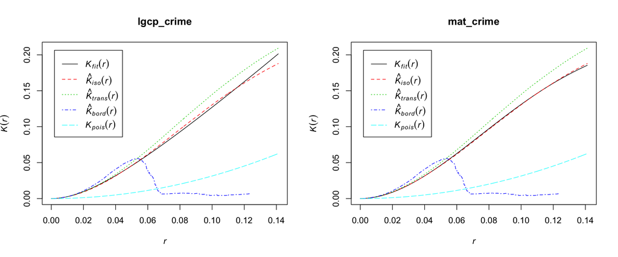

```r
lgcp_crime <- lgcp.estK(crime_ppp, c(sigma2 = 5, alpha = 1))
mat_crime <- matclust.estK(crime_ppp, c(kappa=10, R=0.1))
par(mfrow = c(1,2))
plot(lgcp_crime)
plot(mat_crime)
```

Based on the plots both model appear to give reasonable fits, however the Matern model fit seems to follow the data more closely.

Going back to the map in the beginning of the analysis, it looks like the crime incidents might be clustering around more populated areas, as stated earlier. Thus we now model the crime intensity function as a function of population.

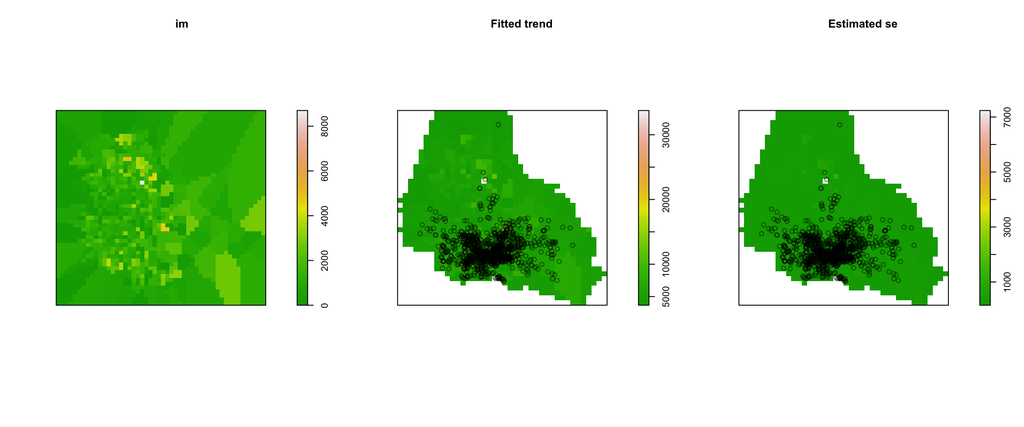

```r
W <- matrix(0,50,50)
lon_range = seq(from = pop_ppp$window$xrange[1], to = pop_ppp$window$xrange[2],length.out = 50)
lat_range = seq(from = pop_ppp$window$yrange[1], to = pop_ppp$window$yrange[2],length.out = 50)

for(i in 1:50) {

  for(j in 1:50) {

          W[i,j]

          loc = c(lon_range[i],lat_range[j])

          index_pop = which.min(rdist.earth.vec(
                  matrix(loc , nrow = length(pop$Tot_population), ncol = 2, byrow = TRUE),
                                pop[,c('Lon','Lat')],miles = FALSE))

          W[i,j] = pop$Tot_population[index_pop]

  }

}



im = as.im(W, crime_ppp)
fit = ppm(crime_ppp ~ im)

par(mfrow = c(1,3))
plot(im, col = terrain.colors(100))
plot(fit, col = terrain.colors(100))
```

```r
fit
```

```
## Nonstationary Poisson process
##
## Log intensity:  ~im
##
## Fitted trend coefficients:
##  (Intercept)           im
## 8.2051089654 0.0002553233
##
##                 Estimate         S.E.      CI95.lo      CI95.hi Ztest
## (Intercept) 8.2051089654 5.082519e-02 8.1054934216 8.3047245092   ***
## im          0.0002553233 2.904573e-05 0.0001983947 0.0003122519   ***
##                   Zval
## (Intercept) 161.437838
## im            8.790389
```

From the fit summary we see that indeed the population density is a statistically significant predictor of crime incident intensity. We see from the plot that most of the fitted points are in the Baltimore city area, and these are the areas with higher density of population as seen in the map in the beginning of the analysis.